# Connaissances et attitudes des femmes sur les violences domestiques et accès aux soins de santé en République d’Angola

KIAMA KISAKASAKA TRESOR

2025-08-23

# I. Introduction

La violence à l’égard des femmes est reconnue comme une grave violation des droits humains et un important problème de santé publique ayant des conséquences considérables sur la santé physique, mentale, sexuelle et reproductive.Les violences domestiques sont les abus physiques, psychologiques, sexuels ou économiques exercés dans un cadre familial, généralement par un partenaire intime ou un membre de la famille. L’objectif 5.2 des ODD prône l’abolition de toutes les formes de violence à l’égard des femmes *[1]*.Une femme sur trois dans le monde a été victime de violence physique ou sexuelle au moins une fois dans sa vie, souvent de la part de son partenaire. La majorité Les cas de violences domestiques ne sont pas signalés dans la majorité des cas en raison de la peur, de la dépendance économique ou de la stigmatisation.Les femmes âgées de 15 à 49 ans sont les plus touchées*[2]*. En Afrique subsaharienne, la violence conjugale est plus fréquente chez les femmes en âge de procréer*[3]* , avec une prévalence de 33 % *[4]*. Les femmes africaines ne sont pas epargné par cette situation qui depend des facteurs socio-démographiques, culturels et familiaux. Dans le cadre de cette étude, nous allons analyser la situation des femmes angolaises en exploitant la base des données de l’enquête démographique et de santé (EDS) de 2016-2017.

# II. Objectifs

Objectif général : Analyser l’ampleur, les formes, et les causes des violences domestiques subies par les  
femmes en Angola afin de proposer des mesures de prévention et de prise en charge.

L’objectif spécifiques :

1. Décrire la prévalence des violences domestiques chez les femmes en Angola.
2. Identifier les facteurs socio-démographiques, culturels et familiaux associés à ces violences.
3. Évaluer l’attitude des femmes au recours à l’aide.
4. Proposer des recommandations pour la prévention, la sensibilisation et l’amélioration de la prise en charge des victimes.

Les données de l’enquête démographique et de santé (EDS) de 2016-2017 en Angola nous ont servis de base pour les analyses.

# III. Méthodes

1.Type d’étude : il s’agit d’une étude quantitative à visée descriptive et analytique.

2.Population cible : Les femmes âgées de 15 ans et plus, résidant en milieu urbain et rural en Angola.

3.Échantillonnage :

- Méthode : échantillonnage aléatoire stratifié (par province, milieu de résidence, etc.)
- Taille : déterminée à partir d’une estimation de la prévalence attendue, avec un niveau de confiance de 95% (Cfr EDS ). 4.Techniques de collecte des données : La collecte des données était effectuée sur base d’un questionnaire  
  structuré (anonyme) portant sur les caractéristiques socio-démographiques, la connaissance des violences, les types de violence, les auteurs et la fréquence et le recours à l’aide.
5. Variables d’intéret:
1. Variables socio-démographiques : Âge, Niveau d’éducation, État matrimonial, Profession, Milieu de résidence, Religion et Indice de richesse du ménage.
2. Variables liées à la violence domestique : Prise de l’alcool par le partenaire, Fréquence violence par le partenaire après prise d’alcool.
3. Recours et aide : Demande de l’aide sollicitée, Personne ou institution de recours, Satisfaction par rapport à la réponse reçue et Connaissance des droits et services existants.
3. Résultats

3.1. Femmes interviewées

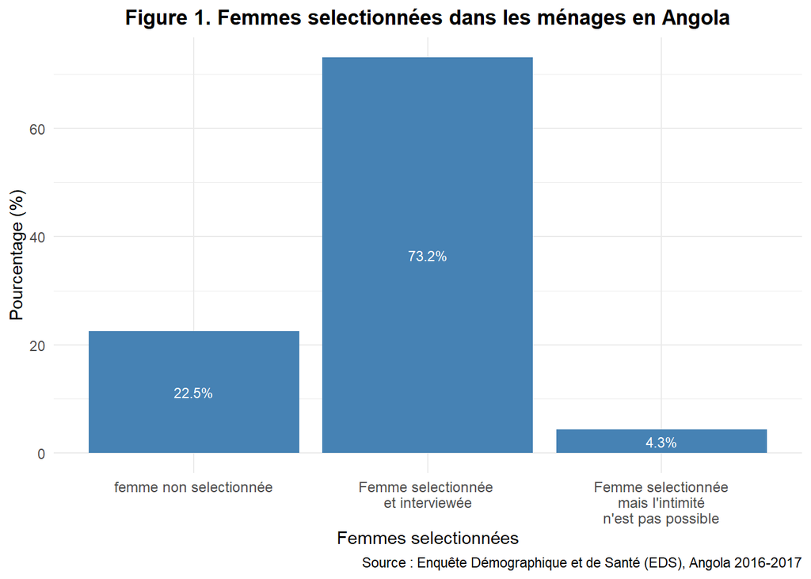

Les femmes selectonnées et ineterviwées pour cette études repésentaient 73% soit 10519 sur 14379 femmes sélectionnées.

Tableau 1 : Caractéristiques sociodémographiques des femmes

| Variable | Modalite | Effectif | Pourcentage |
| --- | --- | --- | --- |
| Lieu de résidence | Urbain | 8935 | 62.1% |
|  | Rural | 5444 | 37.9% |
|  | Total | 14379 | 100.0% |
| Religion | Catholique | 6029 | 41.9% |
|  | Méthodiste | 563 | 3.9% |
|  | Assemblée de Dieu | 1104 | 7.7% |
|  | Église Universelle | 204 | 1.4% |
|  | Témoins de Jéhovah | 353 | 2.5% |
|  | Protestant | 5164 | 35.9% |
|  | Musulman | 43 | 0.3% |
|  | Animiste | 61 | 0.4% |
|  | Sans religion | 802 | 5.6% |
|  | Autre | 56 | 0.4% |
|  | Total | 14379 | 100.0% |
| Fréquence à l’église | Une fois par mois | 659 | 4.6% |
|  | Deux fois par mois | 1135 | 7.9% |
|  | Une fois par semaine | 6406 | 44.6% |
|  | Plus d’une fois par semaine | 4622 | 32.1% |
|  | Aux dates commémoratives | 312 | 2.2% |
|  | N’assiste pas | 1245 | 8.7% |
|  | Total | 14379 | 100.0% |
| Langue parlée à la maison | Portugais | 8561 | 59.5% |
|  | Chokwe/Kioko | 1252 | 8.7% |
|  | Fiote | 120 | 0.8% |
|  | Kikongo/Ukongo | 949 | 6.6% |
|  | Kimbundu | 221 | 1.5% |
|  | Kwanhama | 493 | 3.4% |
|  | Luvale | 88 | 0.6% |
|  | Muhumbi | 220 | 1.5% |
|  | Nganguela | 454 | 3.2% |
|  | Nhaneca | 348 | 2.4% |
|  | Umbundu | 1522 | 10.6% |
|  | Gestuel | 2 | 0.0% |
|  | Autre | 149 | 1.0% |
|  | Total | 14379 | 100.0% |
| Tranche d’âge | 15-19 | 3363 | 23.4% |
|  | 20-24 | 3060 | 21.3% |
|  | 25-29 | 2512 | 17.5% |
|  | 30-34 | 1823 | 12.7% |
|  | 35-39 | 1521 | 10.6% |
|  | 40-44 | 1212 | 8.4% |
|  | 45-49 | 888 | 6.2% |
|  | Total | 14379 | 100.0% |
| Niveau d’études (femme) | Sans instruction | 4047 | 28.1% |
|  | Primaire | 5073 | 35.3% |
|  | Secondaire | 4810 | 33.5% |
|  | Supérieur | 449 | 3.1% |
|  | Total | 14379 | 100.0% |
| Niveau d’études (mari/partenaire) | Sans instruction | 1296 | 16.1% |
|  | Primaire | 2102 | 26.2% |
|  | Secondaire | 3362 | 41.9% |
|  | Supérieur | 501 | 6.2% |
|  | Ne sait pas | 772 | 9.6% |
|  | Total | 8033 | 100.0% |
| Indice de richesse | Très pauvre | 2914 | 20.3% |
|  | Pauvre | 3367 | 23.4% |
|  | Moyen | 3412 | 23.7% |
|  | Riche | 2526 | 17.6% |
|  | Très riche | 2160 | 15.0% |
|  | Total | 14379 | 100.0% |

[figure not shown]

3.2. Caractéristiques sociodémographiques

3.4. Age des femmes

Graphique de la distribution des femmes selon de l’âge

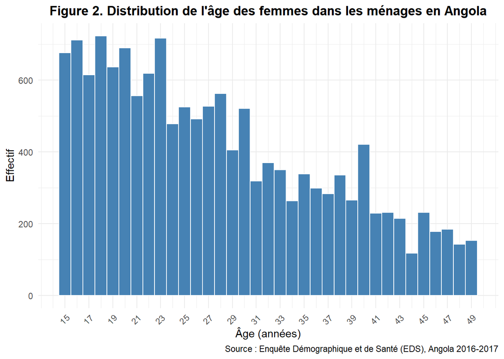

La majorité des femmes ont entre 20 et 35 ans, avec une médiane de 26 ans. La distribution montre une légère concentration vers les jeunes âges.

3.5. Distribution de l’âge des femmes selon le niveau d’études

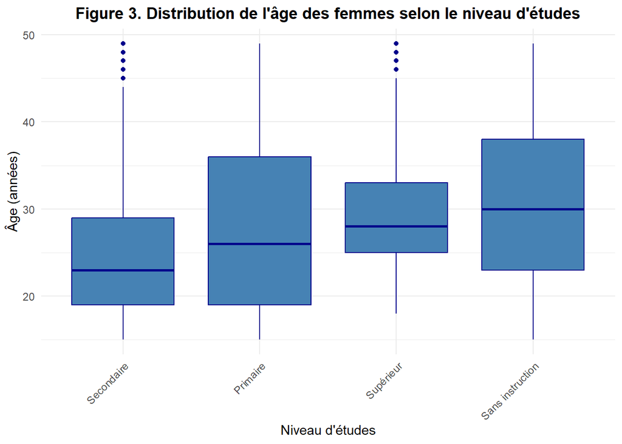

3.6. Connaissance de l’existence des lois contre les abus et les violences domestiques et la planification familiale

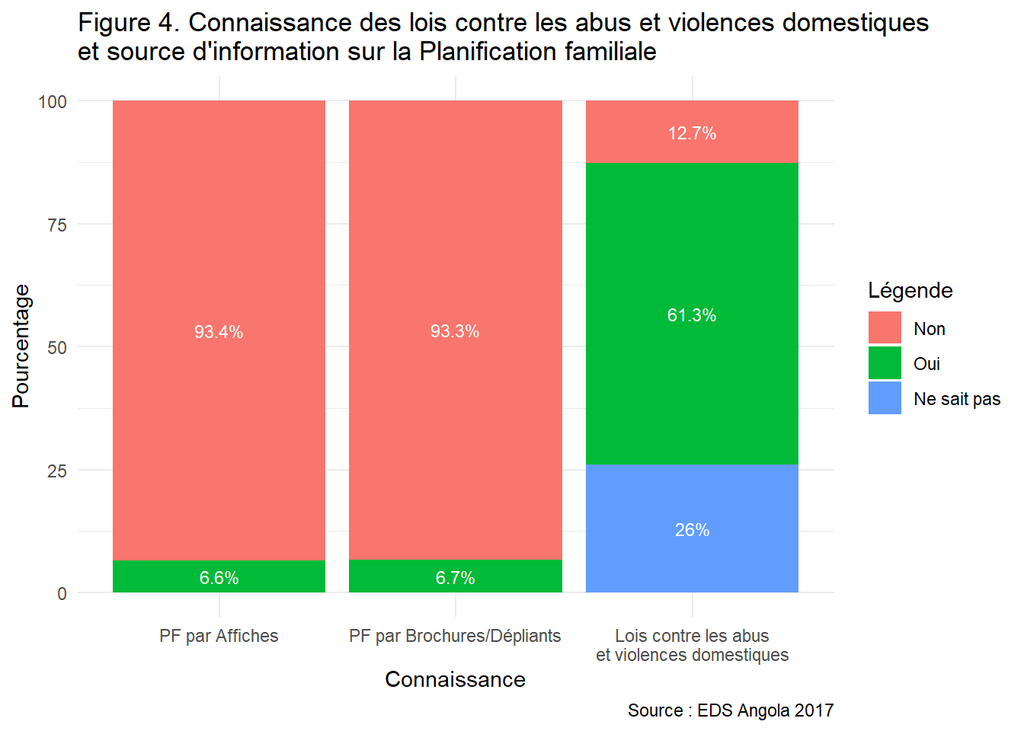

Plus de la moitié des femmes(61,3%) avaient connaissance de l’existence des lois contre les abus et violences domestiques tandis moins d’une femme sur dix (7%) avaient entendu parlé de la planification familiale par au moins un support d’information(affiches, dépliants ou brochures).

3.7. Usage de l’alcool par les femmes

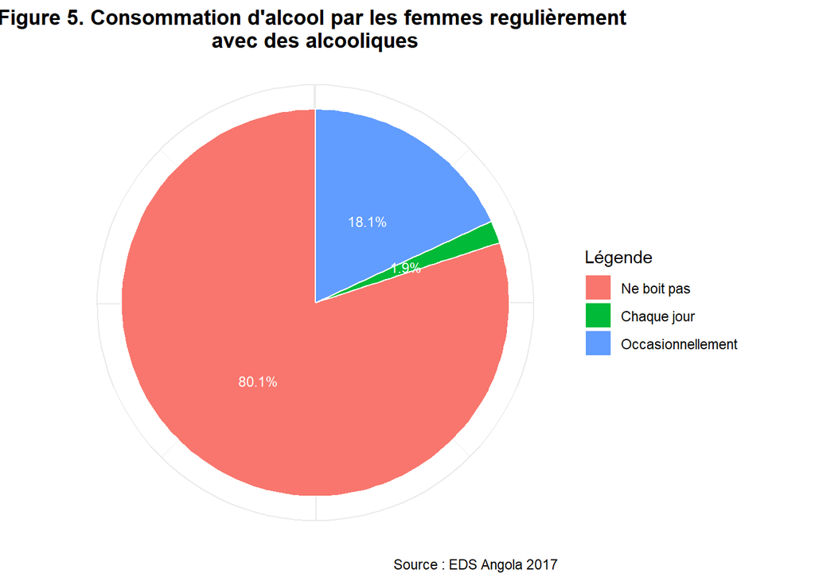

Une femme sur cinq (20%) consomment de l’alcool avec des alcooliques dont 1,9% quotidiennement. Cette fréquence quotidienne peut indiquer une dépendance potentielle ou une exposition accrue à des risques de santé, de violence ou de vulnérabilité sociale.

3.8. Fréquentation des services de santé par les femmes

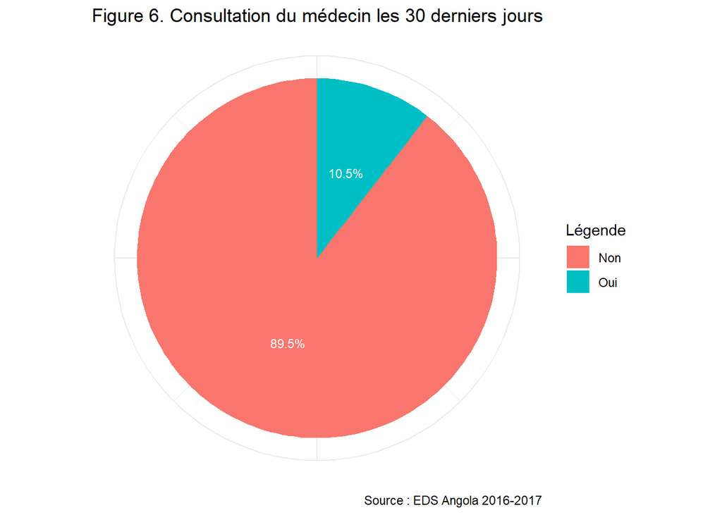

Une femme sur dix (10,5%) avait consulté un médecin les 30 derniers jours. Cela indique un faible recours aux soins médicaux récents parmi les femmes interrogées pouvant entraîner une aggravation des pathologies non prises en charge à temps.

3.9. Niveau de satisfaction des femmes par le service de soins de santé

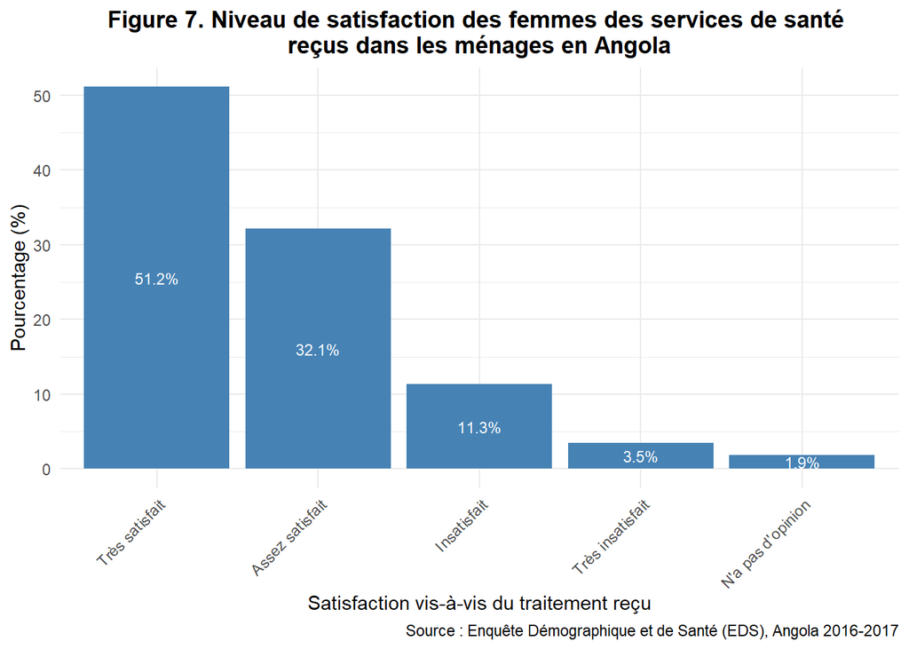

Huit femmes sur dix étaient au moins satisfaites(83%) des services de santé recus dans les formations sanitaires fréquentées mais cela souligne également la nécessité de cibler les sources d’insatisfaction pour améliorer l’expérience des patientes.

3.10. Fréquentation des services de santé par les femmes

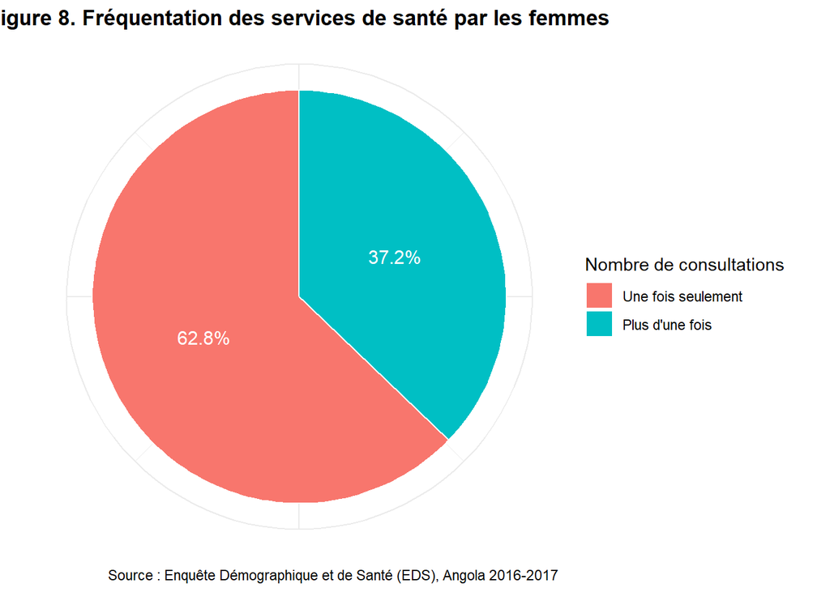

Parmi toutes les femmes ayant consulté un service de santé au cours des 30 derniers jours, 37,2 % ont effectué plus d’une visite médicale dans ce laps de temps.

3.11. Condition d’attente dans les services de soins de santé

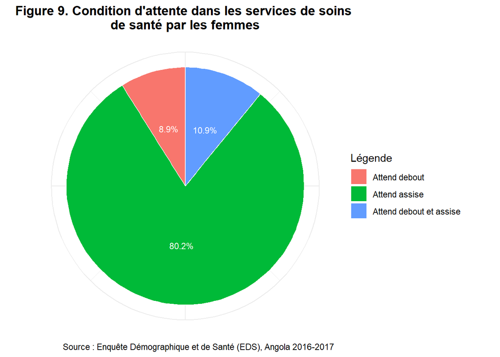

Une femmes sur dix (8,9%) des femmes ont dû attendre uniquement debout, faute de places assises et ont alterné entre debout et assis (10,9 %), ce qui suggère un manque de sièges disponibles ou des conditions d’attente prolongée.

3.12. Compréhension de la langue parlée par le prestataire de soins

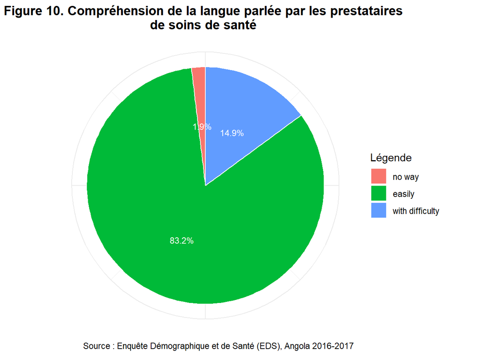

Un peu plus d’une femme sur dix (14,9%) ont eu des difficultés à comprendre la langue du prestataire de soins. La barrière linguistique peut réduire la compréhension des conseils médicaux, affecter l’adhésion au traitement et entraîner des erreurs.

3.13. Violences domestiques

Partenaire ou mari violent après consommation de l’alcool

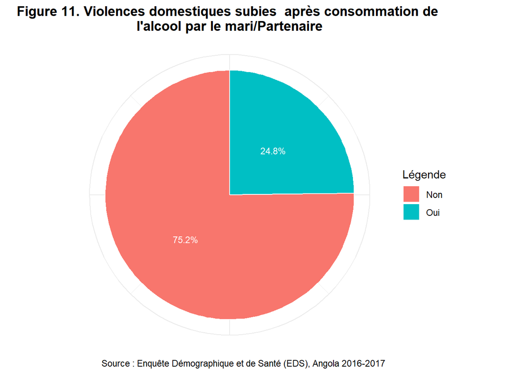

Le quart (24,8%) des femmes ont subies des violences domestiques après que leur mari ou partenaire ait consommé l’alcool. Cette situation met en évidence la nécessité de renforcer les actions de sensibilisation et d’intervention autour de la consommation d’alcool dans les contextes familiaux pour prévenir les violences domestiques.

3.14. Fréquence des violences après consommation de l’alccol par le mari/partenaire les 12 dernièrs mois

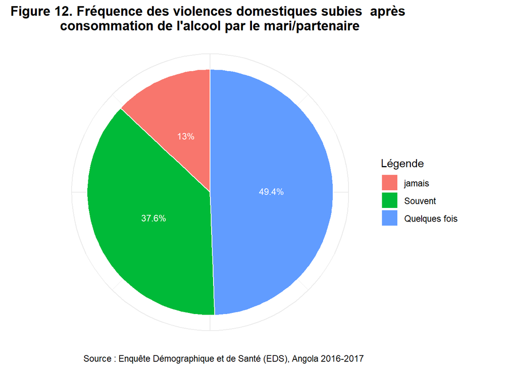

3.15. Raisons de non recours à l’aide chez les femmes victimes des violences domestiques

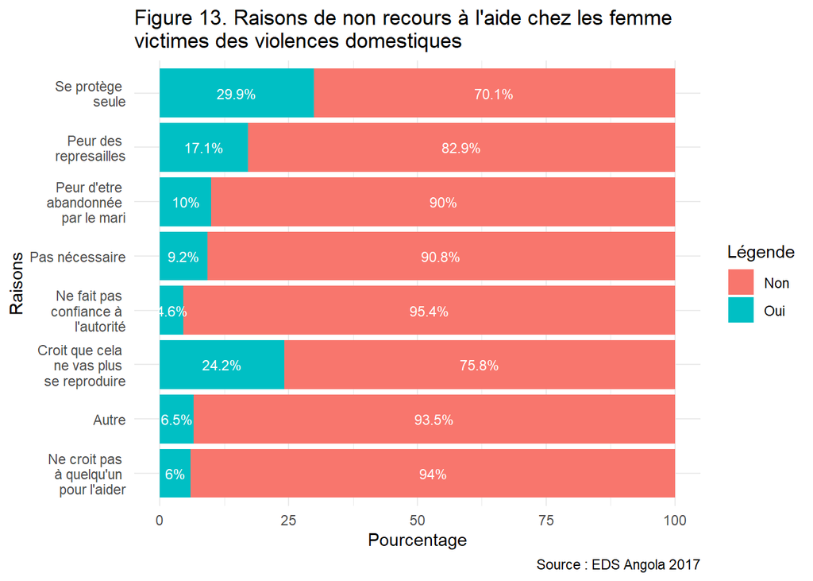

[figure not shown]

3.16. Analyse croisée des facteurs favorisants la violence domestique

3.17. Connaissance des lois contre les abus et violences domestiques en fonction du niveau d’étude des femmes

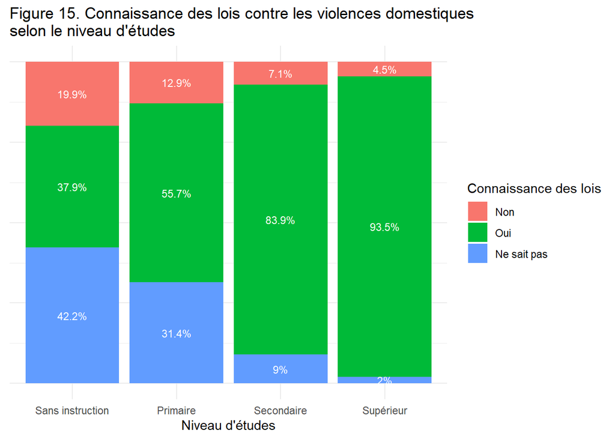

Les femmes avec un niveau d’intruction supérieur (93,5%)ont beaucoup plus connaissance de l’existence des lois contre les abus et violences domestiques d’étude que les femmes de niveau secondaire(83,9), primaire (55,7%) et sans intruction (37,9%).

3.18. Connaissance des lois contre les abus et violences domestiques en fonction du lieu de résidence des femmes

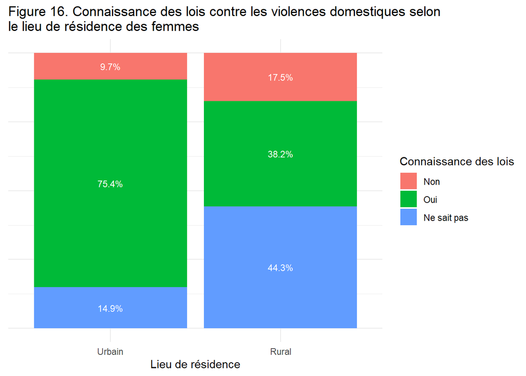

Les femmes habitant les milieux urbains connaissent les lois lois contre les abus et violences domestiques plus (75,4%) que celles des milieux ruraux(38,2%).

3.19. Connaissance des lois contre les abus et violences domestiques en fonction de la religion

[figure not shown]

Huit sur dix femmes fréquentant l’église universelle(87,7%) et Témoins de Jehovah(84,4%) ont une connaissance sur les lois contre les abus et violences domestiques comparativeent à quatre sur dix femmes (44,9%) sans religion.

3.20. Connaissance des lois contre les abus et violences domestiques en fonction de la tranche d’age des femmes.

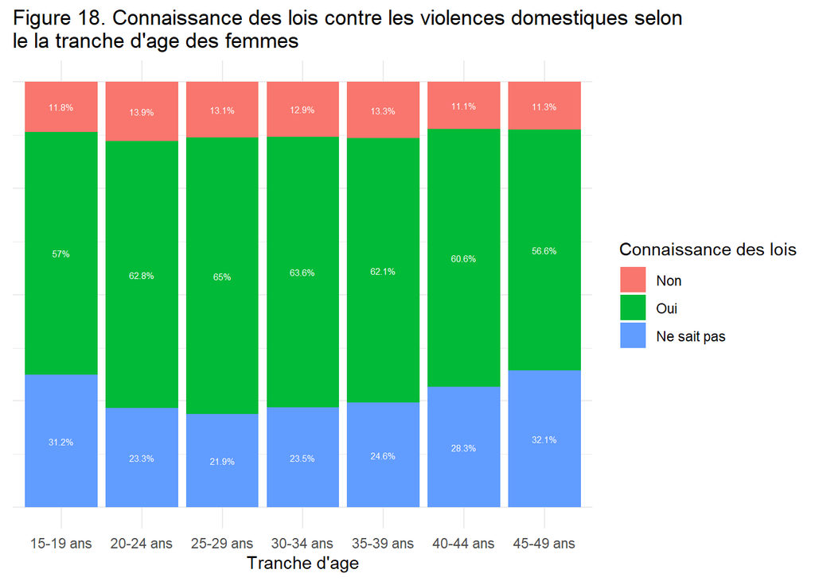

Cinq femmes sur dix agées de moins de 19 ans et plus de 44 ans ont moins de connaissance sur les lois contre les abus et violences domestiques.

3.21. Connaissance des lois contre les abus et violences domestiques en fonction le niveau de richesse

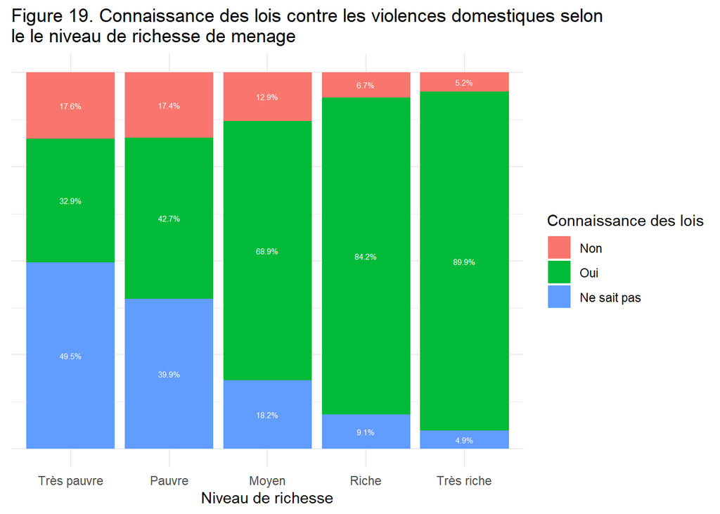

Les femmes issues des ménages avec un niveau de richesse élévé ont plus de connaissance sur les lois contre les abus et violences domestiques.

3.22. Violence du mari après prise d’alcool en fonction du niveau d’instruction

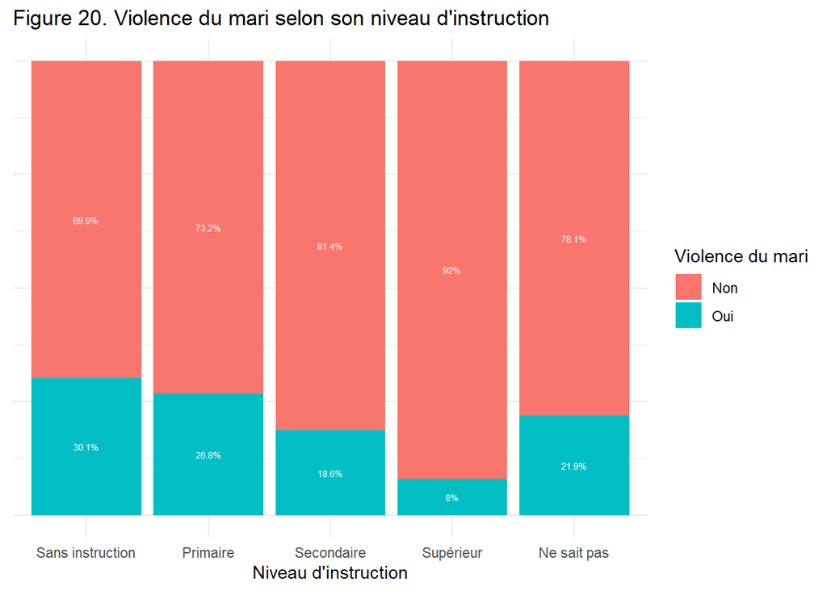

Les mari sans niveau d’intruction(30,1%), de niveau primaire(26,8%) et ceux dont le niveau d’instruction n’est pas connu(21,9%) sont plus violents que ceux ayant un niveau d’instruction plus élevé.

4. Conclusion

*Références*

1.Nations Unies. Objectifs de développement durable des Nations Unies. New York : Nations Unies ; 2015. http://www.un.org/sustainabledeve

2.Données OMS & ONU Femmes

3.Muluneh MD, Stulz V, Francis L, Agho K. Violences sexistes contre les femmes en Afrique subsaharienne : revue systématique et métaanalyse d’études transversales. Revue internationale de recherche environnementale et de santé publique. 2020 ; 17(3): 903.

4. Izugbara CO, Obiyan MO, Degfie TT, Bhatti A. Corrélats de l’intimité. La violence conjugale chez les femmes urbaines en Afrique subsaharienne. PloS one. 2020;15(3):e0230508